# Multiple Comparison Corrections

Kate Schertz

2020-04-29 11:30:29

```r
library(tidyverse)
theme_set(theme_minimal())
set.seed(42)
```

Here we’re reading in the data. This is real data from a study I ran. These are topics that people wrote about in park journals, as discovered by topic modeling. There were 29 parks that served as the locations. Each value is the average prevalence of the topic in journal entries for each park.

```r
parkdata <- read_csv("Study1_ParkEntryAvgs.csv")
head(parkdata)
```

```
## # A tibble: 6 x 11
##   Locations Family   Park `Life & Emotion… `Time & Memorie…    Art Nature
##   <chr>      <dbl>  <dbl>            <dbl>            <dbl>  <dbl>  <dbl>
## 1 4th Stre… 0.0686 0.265            0.0940            0.136 0.0952 0.0928
## 2 American… 0.0956 0.173            0.106             0.123 0.165  0.0767
## 3 Annapoli… 0.104  0.235            0.0749            0.125 0.0499 0.155
## 4 Annapoli… 0.137  0.202            0.0742            0.136 0.0287 0.202
## 5 Anne Aru… 0.109  0.0927           0.116             0.104 0.0199 0.0418
## 6 Baltimor… 0.0902 0.166            0.0945            0.119 0.214  0.102
## # … with 4 more variables: Religion <dbl>, `World & Peace` <dbl>,
## #   Celebration <dbl>, `Spiritual & Life Journey` <dbl>
```

We’re going to “pivot longer” to put all the topics in one column for a quick visualization.

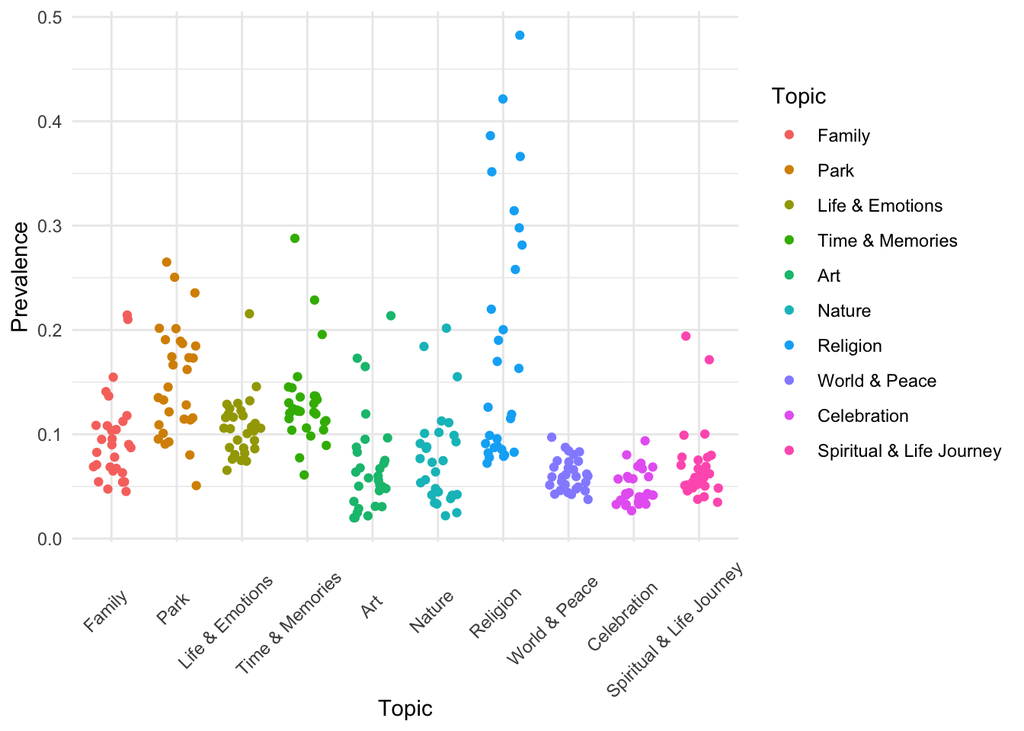

```r
parkdata_long <- parkdata %>% pivot_longer(cols= -Locations, names_to="Topic", values_to = "Prevalence")

#I want my plot to be in the order of my dataframe, instead of alphabetical
parkdata_long$Topic <- factor(parkdata_long$Topic, levels=unique(parkdata_long$Topic))

ggplot(data=parkdata_long) +
  aes(x=Topic, y = Prevalence, color=Topic) +
  geom_jitter(width = .3) +
  theme(axis.text.x = element_text(angle=45, vjust=.65, hjust = .7))
```

Today we’re going to see if the prevelance of Family is significantly different across all the parks from each of the other topics. Since the topics are coming from the same parks, this is 9 paired t-tests.

```r
#Aside: if we wanted to check all topics against all other topics, the total number of tests can be found using the choose() function

t.test(parkdata$Family, parkdata$Park, paired = T)
```

```
##
##  Paired t-test
##
## data:  parkdata$Family and parkdata$Park
## t = -4.2131, df = 28, p-value = 0.0002367
## alternative hypothesis: true difference in means is not equal to 0
## 95 percent confidence interval:
##  -0.08154203 -0.02818999
## sample estimates:
## mean of the differences
##             -0.05486601
```

```r
t.test(parkdata$Family, parkdata$`Life & Emotions`, paired = T)
```

```
##
##  Paired t-test
##
## data:  parkdata$Family and parkdata$`Life & Emotions`
## t = -1.0438, df = 28, p-value = 0.3055
## alternative hypothesis: true difference in means is not equal to 0
## 95 percent confidence interval:
##  -0.03260334  0.01059280
## sample estimates:
## mean of the differences
##             -0.01100527
```

```r
t.test(parkdata$Family, parkdata$`Time & Memories`, paired = T)
```

```
##
##  Paired t-test
##
## data:  parkdata$Family and parkdata$`Time & Memories`
## t = -2.7529, df = 28, p-value = 0.01025
## alternative hypothesis: true difference in means is not equal to 0
## 95 percent confidence interval:
##  -0.060240442 -0.008839022
## sample estimates:
## mean of the differences
##             -0.03453973
```

```r
t.test(parkdata$Family, parkdata$Art, paired = T)
```

```
##
##  Paired t-test
##
## data:  parkdata$Family and parkdata$Art
## t = 2.4747, df = 28, p-value = 0.01966
## alternative hypothesis: true difference in means is not equal to 0
## 95 percent confidence interval:
##  0.004630259 0.049133523
## sample estimates:
## mean of the differences
##              0.02688189
```

```r
t.test(parkdata$Family, parkdata$Nature, paired = T)
```

```
##
##  Paired t-test
##
## data:  parkdata$Family and parkdata$Nature
## t = 1.7036, df = 28, p-value = 0.09952
## alternative hypothesis: true difference in means is not equal to 0
## 95 percent confidence interval:
##  -0.003869575  0.042112611
## sample estimates:
## mean of the differences
##              0.01912152
```

```r
t.test(parkdata$Family, parkdata$Religion, paired = T)
```

```
##
##  Paired t-test
##
## data:  parkdata$Family and parkdata$Religion
## t = -3.7196, df = 28, p-value = 0.0008865
## alternative hypothesis: true difference in means is not equal to 0
## 95 percent confidence interval:
##  -0.14402585 -0.04172936
## sample estimates:
## mean of the differences
##             -0.09287761
```

```r
t.test(parkdata$Family, parkdata$`World & Peace`, paired = T)
```

```
##
##  Paired t-test
##
## data:  parkdata$Family and parkdata$`World & Peace`
## t = 3.8575, df = 28, p-value = 0.000615
## alternative hypothesis: true difference in means is not equal to 0
## 95 percent confidence interval:
##  0.01624672 0.05303944
## sample estimates:
## mean of the differences
##              0.03464308
```

```r
t.test(parkdata$Family, parkdata$Celebration, paired = T)
```

```
##
##  Paired t-test
##
## data:  parkdata$Family and parkdata$Celebration
## t = 5.3391, df = 28, p-value = 1.098e-05
## alternative hypothesis: true difference in means is not equal to 0
## 95 percent confidence interval:
##  0.02919671 0.06554613
## sample estimates:
## mean of the differences
##              0.04737142
```

```r
t.test(parkdata$Family, parkdata$`Spiritual & Life Journey`, paired = T)
```

```
##
##  Paired t-test
##
## data:  parkdata$Family and parkdata$`Spiritual & Life Journey`
## t = 2.2252, df = 28, p-value = 0.0343
## alternative hypothesis: true difference in means is not equal to 0
## 95 percent confidence interval:
##  0.002158551 0.052168689
## sample estimates:
## mean of the differences
##              0.02716362
```

This is giving us a lot of details but let’s make it a little more succinct for easier comparisons.

```r
#Turning off scientific notation
options(scipen=999)

# Saving only the p-values from the t-tests and making them into one vector
nocorrection_p <- as.vector(c(t.test(parkdata$Family, parkdata$Park, paired = T)$p.value,
t.test(parkdata$Family, parkdata$`Life & Emotions`, paired = T)$p.value,
t.test(parkdata$Family, parkdata$`Time & Memories`, paired = T)$p.value,
t.test(parkdata$Family, parkdata$Art, paired = T)$p.value,
t.test(parkdata$Family, parkdata$Nature, paired = T)$p.value,
t.test(parkdata$Family, parkdata$Religion, paired = T)$p.value,
t.test(parkdata$Family, parkdata$`World & Peace`, paired = T)$p.value,
t.test(parkdata$Family, parkdata$Celebration, paired = T)$p.value,
t.test(parkdata$Family, parkdata$`Spiritual & Life Journey`, paired = T)$p.value))

# Saving the topic names in order that the p-value represents. Since I ran the tests in order of columns in the data frame, we can use the column names, removing Locations and Family
names <- colnames(parkdata)[-(1:2)]

tests_df <- tibble(names, nocorrection_p)
tests_df
```

```
## # A tibble: 9 x 2
##   names                    nocorrection_p
##   <chr>                             <dbl>
## 1 Park                          0.000237
## 2 Life & Emotions               0.306
## 3 Time & Memories               0.0103
## 4 Art                           0.0197
## 5 Nature                        0.0995
## 6 Religion                      0.000886
## 7 World & Peace                 0.000615
## 8 Celebration                   0.0000110
## 9 Spiritual & Life Journey      0.0343
```

```r
# Which are signifiant with no multiple comparison correction at an alpha of .05?
alpha <- .05
tests_df <- tests_df %>% arrange(nocorrection_p) %>% mutate(SigOrigP = nocorrection_p < alpha)
tests_df
```

```
## # A tibble: 9 x 3
##   names                    nocorrection_p SigOrigP
##   <chr>                             <dbl> <lgl>
## 1 Celebration                   0.0000110 TRUE
## 2 Park                          0.000237  TRUE
## 3 World & Peace                 0.000615  TRUE
## 4 Religion                      0.000886  TRUE
## 5 Time & Memories               0.0103    TRUE
## 6 Art                           0.0197    TRUE
## 7 Spiritual & Life Journey      0.0343    TRUE
## 8 Nature                        0.0995    FALSE
## 9 Life & Emotions               0.306     FALSE
```

## Bonferroni correction

```r
numtests <- nrow(tests_df)
tests_df <- tests_df %>% mutate(SigBonferroniP = nocorrection_p < alpha/numtests)
tests_df
```

```
## # A tibble: 9 x 4
##   names                    nocorrection_p SigOrigP SigBonferroniP
##   <chr>                             <dbl> <lgl>    <lgl>
## 1 Celebration                   0.0000110 TRUE     TRUE
## 2 Park                          0.000237  TRUE     TRUE
## 3 World & Peace                 0.000615  TRUE     TRUE
## 4 Religion                      0.000886  TRUE     TRUE
## 5 Time & Memories               0.0103    TRUE     FALSE
## 6 Art                           0.0197    TRUE     FALSE
## 7 Spiritual & Life Journey      0.0343    TRUE     FALSE
## 8 Nature                        0.0995    FALSE    FALSE
## 9 Life & Emotions               0.306     FALSE    FALSE
```

## False Detection Rate (Benjamini-Hochberg procedure)

```r
#Since we already ordered the rows by p-value, this is the rank of p-values.
tests_df <- tests_df %>% mutate(i = row_number())

#I want to check Q=.05 and Q=.25, but usually you'd just pick one before you ran your study, so you could set Q as a variable
tests_df <- tests_df %>%
  mutate(BH_q05 = (i/numtests)*.05, q05_sig = nocorrection_p < BH_q05,
         BH_q25 = (i/numtests)*.25, q25_sig = nocorrection_p < BH_q25)
tests_df[,-4]
```

```
## # A tibble: 9 x 8
##   names             nocorrection_p SigOrigP     i  BH_q05 q05_sig BH_q25 q25_sig
##   <chr>                      <dbl> <lgl>    <int>   <dbl> <lgl>    <dbl> <lgl>
## 1 Celebration            0.0000110 TRUE         1 0.00556 TRUE    0.0278 TRUE
## 2 Park                   0.000237  TRUE         2 0.0111  TRUE    0.0556 TRUE
## 3 World & Peace          0.000615  TRUE         3 0.0167  TRUE    0.0833 TRUE
## 4 Religion               0.000886  TRUE         4 0.0222  TRUE    0.111  TRUE
## 5 Time & Memories        0.0103    TRUE         5 0.0278  TRUE    0.139  TRUE
## 6 Art                    0.0197    TRUE         6 0.0333  TRUE    0.167  TRUE
## 7 Spiritual & Life…      0.0343    TRUE         7 0.0389  TRUE    0.194  TRUE
## 8 Nature                 0.0995    FALSE        8 0.0444  FALSE   0.222  TRUE
## 9 Life & Emotions        0.306     FALSE        9 0.05    FALSE   0.25   FALSE
```

Let’s visualize this to see how different p-values drop out based on the Q you choose.

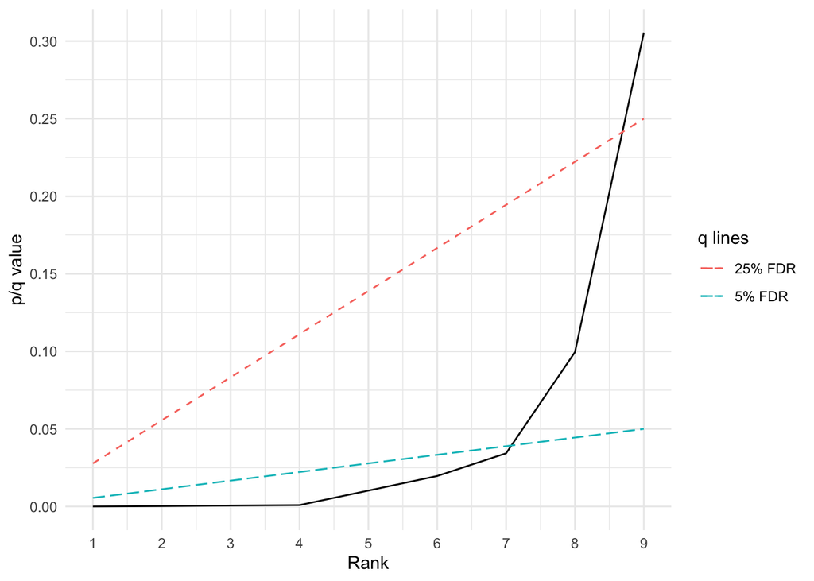

```r
ggplot(data=tests_df) + aes(x=i, y=nocorrection_p) +
  geom_line() +
  geom_line(aes(x=i, y=BH_q05, color="5% FDR"), linetype="longdash") +
  geom_line(aes(x=i, y=BH_q25, color="25% FDR"), linetype="dashed") +
  scale_x_continuous(breaks=seq(1,9,1)) +
  scale_y_continuous(breaks=seq(0,.35,.05)) +
  labs(x="Rank",y="p/q value", color='q lines')
```

Let’s also visualize what happens to the “q lines” when you change the number of tests. Let’s say we had tested all topics against all others; that would be 45 t-tests.

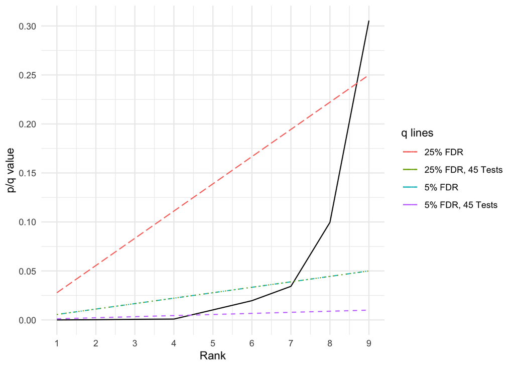

```r
tests_df <- tests_df %>%
  mutate(BH_q05_moretest = (i/45)*.05, q05_moretest_sig = nocorrection_p < BH_q05_moretest,
         BH_q25_moretest = (i/45)*.25, q25_moretest_sig = nocorrection_p < BH_q25_moretest)

ggplot(data=tests_df) + aes(x=i, y=nocorrection_p) +
  geom_line() +
  geom_line(aes(x=i, y=BH_q05, color="5% FDR"), linetype="dotdash") +
  geom_line(aes(x=i, y=BH_q25, color="25% FDR"), linetype="longdash") +
  geom_line(aes(x=i, y=BH_q05_moretest, color="5% FDR, 45 Tests"), linetype="dashed")+
  geom_line(aes(x=i, y=BH_q25_moretest, color="25% FDR, 45 Tests"), linetype="dotted")+
  scale_x_continuous(breaks=seq(1,9,1)) +
  scale_y_continuous(breaks=seq(0,.35,.05)) +
  labs(x="Rank",y="p/q value", color='q lines')
```

## Using R’s built in functions

This function takes a vector of unadjusted p-values and returns the adjusted p-values, which you then compare to your alpha. Instead of dividing alpha by the number of tests, the bonferroni correction is multiplying the p-values by the number of tests (max = 1). For Benjamini-Hochberg, instead of generating the q-value to compare to your p-values, it’s adjusting the p-value directly (p-value*number of test/rank) to compare to your FDR.

```r
#Bonferroni
tests_df$autoBonferroni <- p.adjust(tests_df$nocorrection_p, method="bonferroni")
tests_df <- tests_df %>% mutate(AutoBon_sig = autoBonferroni < alpha)
tests_df
```

```
## # A tibble: 9 x 15
##   names nocorrection_p SigOrigP SigBonferroniP     i  BH_q05 q05_sig BH_q25
##   <chr>          <dbl> <lgl>    <lgl>          <int>   <dbl> <lgl>    <dbl>
## 1 Cele…      0.0000110 TRUE     TRUE               1 0.00556 TRUE    0.0278
## 2 Park       0.000237  TRUE     TRUE               2 0.0111  TRUE    0.0556
## 3 Worl…      0.000615  TRUE     TRUE               3 0.0167  TRUE    0.0833
## 4 Reli…      0.000886  TRUE     TRUE               4 0.0222  TRUE    0.111
## 5 Time…      0.0103    TRUE     FALSE              5 0.0278  TRUE    0.139
## 6 Art        0.0197    TRUE     FALSE              6 0.0333  TRUE    0.167
## 7 Spir…      0.0343    TRUE     FALSE              7 0.0389  TRUE    0.194
## 8 Natu…      0.0995    FALSE    FALSE              8 0.0444  FALSE   0.222
## 9 Life…      0.306     FALSE    FALSE              9 0.05    FALSE   0.25
## # … with 7 more variables: q25_sig <lgl>, BH_q05_moretest <dbl>,
## #   q05_moretest_sig <lgl>, BH_q25_moretest <dbl>, q25_moretest_sig <lgl>,
## #   autoBonferroni <dbl>, AutoBon_sig <lgl>
```

```r
tests_df[,-c(5:13)]
```

```
## # A tibble: 9 x 6
##   names        nocorrection_p SigOrigP SigBonferroniP autoBonferroni AutoBon_sig
##   <chr>                 <dbl> <lgl>    <lgl>                   <dbl> <lgl>
## 1 Celebration       0.0000110 TRUE     TRUE                0.0000988 TRUE
## 2 Park              0.000237  TRUE     TRUE                0.00213   TRUE
## 3 World & Pea…      0.000615  TRUE     TRUE                0.00554   TRUE
## 4 Religion          0.000886  TRUE     TRUE                0.00798   TRUE
## 5 Time & Memo…      0.0103    TRUE     FALSE               0.0923    FALSE
## 6 Art               0.0197    TRUE     FALSE               0.177     FALSE
## 7 Spiritual &…      0.0343    TRUE     FALSE               0.309     FALSE
## 8 Nature            0.0995    FALSE    FALSE               0.896     FALSE
## 9 Life & Emot…      0.306     FALSE    FALSE               1         FALSE
```

```r
#Benjamini-Hochberg
fdr <- .05
tests_df$autoBH <- p.adjust(tests_df$nocorrection_p, method="BH")
tests_df <- tests_df %>% mutate(AutoBH_sig = autoBH < fdr)
tests_df[,-c(4,7:15)]
```

```
## # A tibble: 9 x 7
##   names                nocorrection_p SigOrigP     i  BH_q05   autoBH AutoBH_sig
##   <chr>                         <dbl> <lgl>    <int>   <dbl>    <dbl> <lgl>
## 1 Celebration               0.0000110 TRUE         1 0.00556  9.88e-5 TRUE
## 2 Park                      0.000237  TRUE         2 0.0111   1.07e-3 TRUE
## 3 World & Peace             0.000615  TRUE         3 0.0167   1.85e-3 TRUE
## 4 Religion                  0.000886  TRUE         4 0.0222   1.99e-3 TRUE
## 5 Time & Memories           0.0103    TRUE         5 0.0278   1.85e-2 TRUE
## 6 Art                       0.0197    TRUE         6 0.0333   2.95e-2 TRUE
## 7 Spiritual & Life Jo…      0.0343    TRUE         7 0.0389   4.41e-2 TRUE
## 8 Nature                    0.0995    FALSE        8 0.0444   1.12e-1 FALSE
## 9 Life & Emotions           0.306     FALSE        9 0.05     3.06e-1 FALSE
```

## Flexible Functions

These functions take a vector of p-values and return TRUE/FALSE for whether the p-value survives your multiple comparison correction.

```r
Bonferroni <- function(p, alpha=.05){
  tests <- length(p)
  bonf_alpha <- alpha/tests
  for (i in 1:length(p)){
    pass <- p[i] < bonf_alpha
    print(paste(as.character(round(p[i],5)), pass))
  }
}

Bonferroni(tests_df$nocorrection_p, .05)
```

```
## [1] "0.00001 TRUE"
## [1] "0.00024 TRUE"
## [1] "0.00062 TRUE"
## [1] "0.00089 TRUE"
## [1] "0.01025 FALSE"
## [1] "0.01966 FALSE"
## [1] "0.0343 FALSE"
## [1] "0.09952 FALSE"
## [1] "0.30552 FALSE"
```

```r
BenjaminiHochberg <- function(p, q=.25){
  p_sorted <- sort(p)
  tests <- length(p)
  for (i in 1:length(p)){
    pass <- p[i] < (i/tests)*q
    print(paste(as.character(round(p[i],5)), pass))
  }
}

BenjaminiHochberg(tests_df$nocorrection_p, q=.05)
```

```
## [1] "0.00001 TRUE"
## [1] "0.00024 TRUE"
## [1] "0.00062 TRUE"
## [1] "0.00089 TRUE"
## [1] "0.01025 TRUE"
## [1] "0.01966 TRUE"
## [1] "0.0343 TRUE"
## [1] "0.09952 FALSE"
## [1] "0.30552 FALSE"
```

## Extra: Holm-Bonferroni

(a slightly less conservative version of Bonferroni) For the most significant p-value, you divide by the number of tests. For the next p-value, you subtract 1 from the number of tests, because that’s the number of tests you have remaining…continuing until you reach a non-significant test. With these data, it didn’t make a difference.

```r
tests_df <- tests_df %>% mutate(HBsig = nocorrection_p < alpha/(numtests-i+1))
tests_df[,-c(5:17)]
```

```
## # A tibble: 9 x 5
##   names                    nocorrection_p SigOrigP SigBonferroniP HBsig
##   <chr>                             <dbl> <lgl>    <lgl>          <lgl>
## 1 Celebration                   0.0000110 TRUE     TRUE           TRUE
## 2 Park                          0.000237  TRUE     TRUE           TRUE
## 3 World & Peace                 0.000615  TRUE     TRUE           TRUE
## 4 Religion                      0.000886  TRUE     TRUE           TRUE
## 5 Time & Memories               0.0103    TRUE     FALSE          FALSE
## 6 Art                           0.0197    TRUE     FALSE          FALSE
## 7 Spiritual & Life Journey      0.0343    TRUE     FALSE          FALSE
## 8 Nature                        0.0995    FALSE    FALSE          FALSE
## 9 Life & Emotions               0.306     FALSE    FALSE          FALSE
```

# Reference:

Full dataset available online: https://doi.org/10.1016/j.cognition.2018.01.011